# Western blot analysis

These notes are written for Stoebel Lab quantification of RpoS blots. You may need to work with Dan to modify the stanards or code below for your specific work. In particular the code was written with one independent variable in mind. (I.e. one strain at many time points, one strain at many RpoS levels, or many strains at many time points.) If you’ve got something more complicated, we can modify things.

##Setting up your data

For **each** western blot, create a folder. The folder name should include the date that the blot was done on, and it should match the date entry in your lab notebook so that we can go back and doublecheck specifics of the experiment. This folder should contain the following:

1. A .tif file of the blot, with no added marks to it. This should be grayscale, with background in white and bands in black.
2. A .tif file of the image, showing the boxes used for quantification of band intensities.
3. A .tif file of the revert stained membrane, with no added marks to it. This should be grayscale, with background in white and bands in black.
4. A .tif file of the revert stained membrane, showing the boxes used for quantification of band intensities.
5. A Keynote file with the image of the blot (#1 above) labeling all lanes, strain numbers, experimental conditions, etc. Do not use PowerPoint, which often downsamples the resolution of images. If you do not have Keynote on your computer, you are welcome to use the lab iMac.
6. The Excel file of exported RpoS band intesities. If you also quantified another protein, do not include them in this file. In this spreadsheet, define a column named “Lane”. In this column, label each signal with the lane it came from. This is so that the protein signal will be matched up with the correct lane signal from the imaging of the REVERT staining. Define the lane (or rectangle around the protein band) containing from the ladder as 1. All other lanes/rectangles should be numbered according to what lane they are in. This is because the “Name” column that is generated by Image Studio may not correspond between the total protein blot spreadsheet data and the single band of protein blot spreadsheet data. In addition to “Lane”, add other columns to define the variables that are important for your experiment (I.e. strain #, species, muations, growth time point, OD, % arabinose added, %RpoS, etc.)
7. The Excel file of exported Revert stain intensities or RpoD band intensities, if you used this method. You should add the “Lane” column, exactly as above. You don’t need to add the other information, as the samples will be matched up by the script.

This code makes heavy use of R for Data Science (http://r4ds.had.co.nz/) You can read lots more about ggplot, filter, the pipe (%>%), etc. Play with the code here to try to understand what is going on.

Start by importing the data

```r
library(tidyverse)
library(readxl)
theme_set(theme_minimal())

#The number refers to a day, the letter refers to first or second gel on the same day.#

#June 12
revert1a <- read_excel("June 19 2019/OSa OSb/revert OSa OSb 2019 06 19.xls")
rpoS1a <- read_excel("June 19 2019/OSa OSb/stain_OSa_OSb_2019-06-18.xls")


#July 01
revert2a <- read_excel("July 01 2019/OSa OSb/revert OSa OSb 2019 07 01.xls")
rpoS2a <- read_excel("July 01 2019/OSa OSb/stain OSa OSb 2019 07 01.xls")

revert2b <- read_excel("July 01 2019/OSc OSd/revert OSc OSd 2019 07 01.xls")
rpoS2b <- read_excel("July 01 2019/OSc OSd/stain OSc OSd 2019 07 01.xls")
```

Normalize all data by Revert levels

```r
source("westernHelperFunctions.R") #This loads the helper functions for normalization, etc.

#calling the function in order to get the normalized signal for every set of Western blots

blotData1a <- normalizeSingleBlot(revert1a, rpoS1a)
#blotData1b <- normalizeSingleBlot(revert1b, rpoS1b)
blotData2a <- normalizeSingleBlot(revert2a, rpoS2a)
blotData2b <- normalizeSingleBlot(revert2b, rpoS2b)
#blotData3a <- normalizeSingleBlot(revert3a, rpoS3a)
#blotData3b <- normalizeSingleBlot(revert3b, rpoS3b)
```

```r
allData <- bind_rows(blotData1a, blotData2a,  blotData2b)
```

Get just the wt data for trial A

```r
#allData %>%
#  filter(Genotype == "wt" & Trial == "A")  %>%
#  group_by(`Time`) %>%
#  summarise(meanDensity = mean(OD), meanRpoS = mean(RpoSratio), n = length(OD)) %>%
  #View()#

#  write_delim(path = "mean OD and RpoS levels.txt", delim = "\t")
```

This just gives all the summarised data in a data frame

```r
by_time <- group_by(allData, Time, Genotype, Trial, Experiment) #could try grouping by trial
meanData <- summarise(by_time, meanDensity = mean(OD), meanRpoS = mean(RpoSratio), n = length(OD))
meanData <- filter(meanData, Experiment == "osmo shock", Genotype=="wt")
```

We can plot the mean data of all trials as RpoS levels as a function of time.

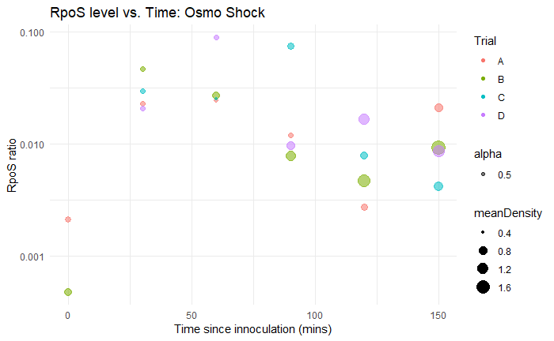

```r
ggplot(meanData) +
  geom_point(aes(x = `Time`, y = `meanRpoS`, size=meanDensity, color = Trial, alpha = .5)) +
  scale_y_log10() +
  labs(x = "Time since innoculation (mins)", y = "RpoS ratio", title = "RpoS level vs. Time: Osmo Shock")
```

Alternatively, we can plot the data of as density as a function of time.

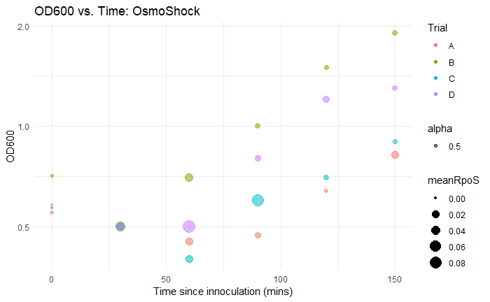

```r
ggplot(meanData) +
  geom_point(aes(x = `Time`, y = `meanDensity`, size=meanRpoS, color = Trial, alpha = .5)) +
  scale_y_log10() +
  labs(x = "Time since innoculation (mins)", y = "OD600", title = "OD600 vs. Time: OsmoShock")
```